# Intensity analysis of land change in Plum Island Ecosystems by interval, category, and transition

Sam Khallaghi

2018-09-25

## Data

This tutorial illustrates the concepts by using three maps of land categories at the years 1985, 1991, and 1999 for the Plum Island Ecosystems (PIE). The PIE site covers 1134 square kilometers of suburban land north of Boston, Massachusetts, USA. All maps have the same spatial extent and the same categories. Each map has a pixel resolution of 30 m × 30 m, wherein each pixel represents one of seven categories: Built, Agriculture, Range, Forest, Water, Wetland, and Barren.

The maps are available in “rst” format and included in the package. The intensity.analysis package can read all supported raster formats through RGDAL library. The first step is to read the raster files and put them in a list.

```r
# Read the raster files from example data.
raster_1985 <- raster(system.file("external/p_landuse7_1985_01.rst", package="intensity.analysis"))
raster_1991 <- raster(system.file("external/p_landuse7_1991_01.rst", package="intensity.analysis"))
raster_1999 <- raster(system.file("external/p_landuse7_1999_01.rst", package="intensity.analysis"))
```

```r
# Make a list of raster objects.
raster.layers <- list(raster_1985, raster_1991, raster_1999)
```

Next, using the **multicrosstab** function, we overlay the 1985 map with the 1991 map and then the 1991 map with the 1999 map to produce a crosstabulation table for each time interval. The output of the function is a list containing crosstabulation tables in which the rows are the categories of the initial time and the columns are the categories of the final time of each interval. The **multicrosstab** function needs two more arguments namely time points and categories, both as character vectors. The raster layer list and time points vector must have the years in the same chronological order. The names in the categories vector must be equivalent to the ID of categories in the raster attribute table of the categorical maps.

```r
# character vector of time points.
time.points <- c("1985","1991","1999")

# character vector of land categories.
categories <- c("Built","Agriculture","Range", "Forest", "Water", "Wetland", "Barren")

# Calling crosstabulation function.
crosstabulation <- multicrosstab(raster.layers, time.points, categories)
crosstabulation
```

```
#> [[1]]
#>              Built Agriculture Range Forest Water Wetland Barren
#> Built       477651         122   342   2376    19      44    335
#> Agriculture   5858       57868   356    134     0       0      0
#> Range         3036          34 23108    371     4       0      0
#> Forest       25090         113   599 517789    72      85    434
#> Water           25           0     0      0 25000       0      0
#> Wetland        114           0     5    558    22  107290     16
#> Barren        1578           0    38    350     0       0   9305
#>
#> [[2]]
#>              Built Agriculture Range Forest Water Wetland Barren
#> Built       504079          28   499   8550     2     150     44
#> Agriculture   5609       51661   558    291     0       0     18
#> Range         4062         149 20012    213     0      12      0
#> Forest       27146         165   463 492813    16     510    465
#> Water            0           0     0      9 24744     148    216
#> Wetland        208           0    31   1556    53  105546     25
#> Barren        2221           0     0     49   335      33   7452
```

We now proceed to the three level intensity analysis using crosstabulation tables for each consecutive pair of time points.

## Interval level

Interval level analysis shows the size of change and the speed of change during each time interval. Analysis denotes the speed of change during each interval as either slow or fast.

Execution of the **IIA** function, generates proper graphs that show the “Change Size” and “Change Intensity” for all time intervals.

```r
# Calling IIA(Interval Intensity Analysis) function.
IIA.output <- IIA(crosstabulation, time.points)
```

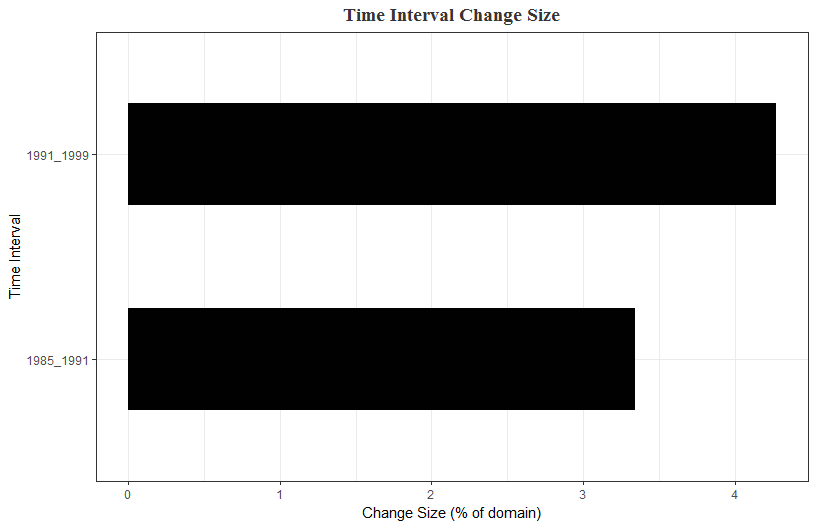

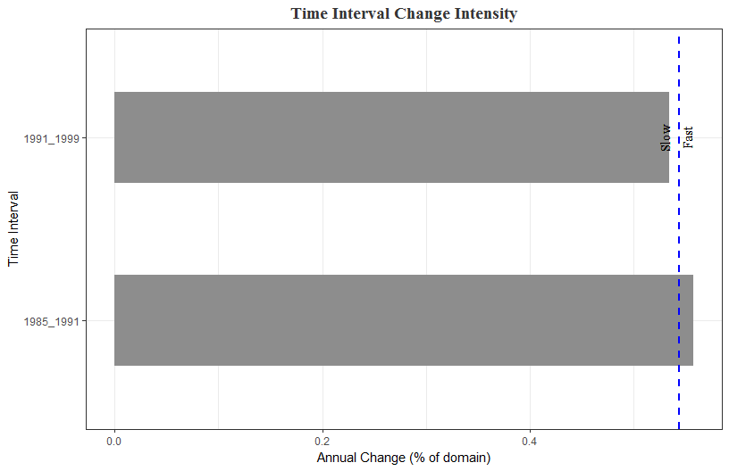

The package also produces numerical output for “Change Size”, “Uniform Intensity of Change”, “Uniform Change all Intervals”, “Interval behavior” for each interval.

```
#> $Change.Size
#> [1] 42130 53834
#>
#> $Uniform.Intensity.of.Change
#> [1] 0.005572128 0.005340077
#>
#> $Uniform.Change.all.Intervals
#> [1] 0.005439527
#>
#> $Interval.Behavior
#> $Interval.Behavior[[1]]
#> [1] "Fast"
#>
#> $Interval.Behavior[[2]]
#> [1] "Slow"
```

The **IIA2csv** function reads the output of the **IIA** function and a directory variable as arguments then makes a CSV report of the interval level intensity analysis and saves it in a folder named “CSVOutput” inside the provided path. The CSV file is named: “IntervalLevelIntensityAnalysis”.

```r
# Define a variable with the direction to store the csv results.
path <- "C:/AnalysisResults"
IIA2csv(IIA.output, path)
```

## Category level

THe category level computes the size of annual change for each category in the form of its annual gross loss and annual gross gain during each time interval. The package also computes the **Annual Loss Intensity** by computing the size of each gross annual loss divided by the size of the category at the initial time point of the interval. The package computes the **Annual Gain Intensity** by computing the size of each gross annual gain divided by the size of the category at the final time point of the interval. Comparing these intensities with uniform change in the study area reveals the land categories that are relatively dormant versus active in terms of loss and gain during a given time interval and provides the means to explore the stability of the pattern across time intervals.

Execution of the **CIA** function, generates graphs that show the “Annual size” and “Annual intensity” of loss and gain for each category during each time interval. If the input data are raster maps, then **# of elements** in the figures means the number of pixels.

```r
# Calling CIA(Category Intensity Analysis) function.
CIA.output <- CIA(crosstabulation, time.points, categories)
```

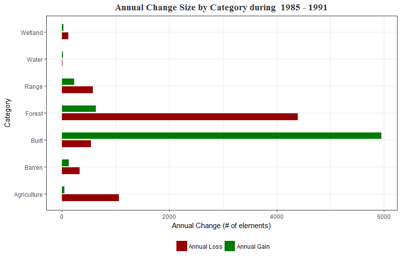

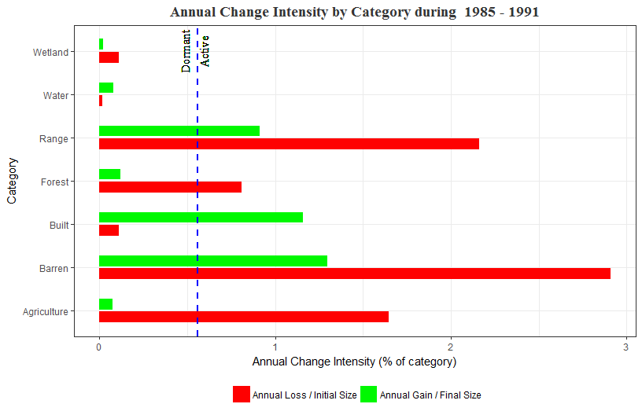

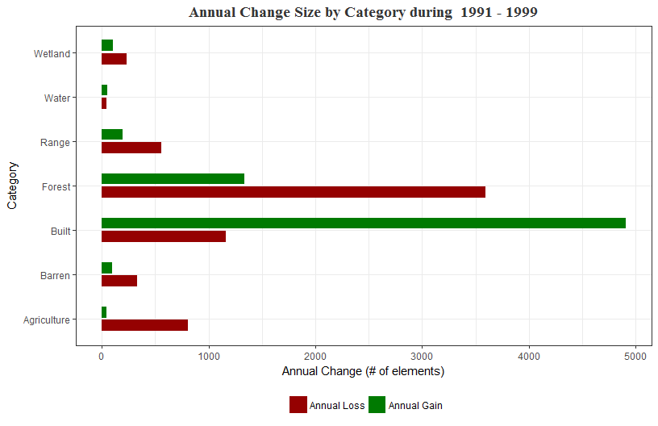

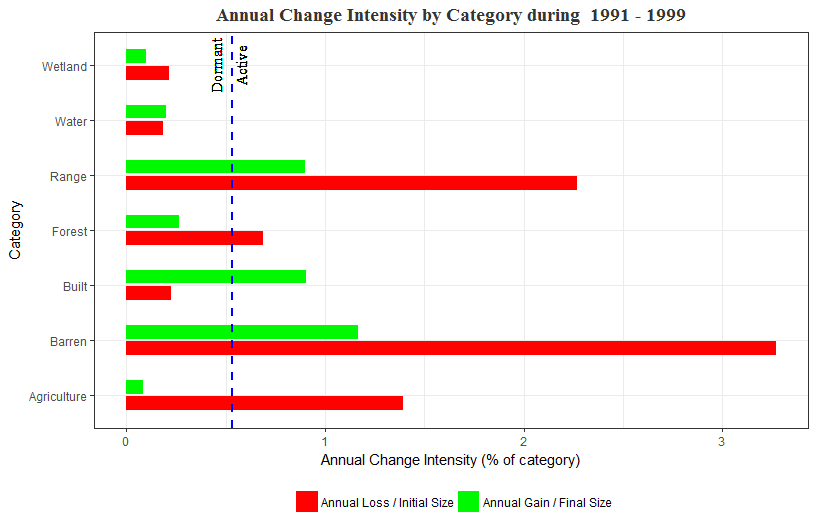

The package returns also numerical values for “Annual Gross Loss”, “Annual Gross Gain”, “Annual Loss Intensity”, “Annual Gain Intensity”, “Uniform Category Intensity”, “Annual Loss Intensity Behavior” and “Annual Gain Intensity Behavior”.

```
#> $Annual.Gross.Loss
#> $Annual.Gross.Loss[[1]]
#>       Built Agriculture       Range      Forest       Water     Wetland
#>  539.666667 1058.000000  574.166667 4398.833333    4.166667  119.166667
#>      Barren
#>  327.666667
#>
#> $Annual.Gross.Loss[[2]]
#>       Built Agriculture       Range      Forest       Water     Wetland
#>    1159.125     809.500     554.500    3595.625      46.625     234.125
#>      Barren
#>     329.750
#>
#>
#> $Annual.Gross.Gain
#> $Annual.Gross.Gain[[1]]
#>       Built Agriculture       Range      Forest       Water     Wetland
#>  5950.16667    44.83333   223.33333   631.50000    19.50000    21.50000
#>      Barren
#>   130.83333
#>
#> $Annual.Gross.Gain[[2]]
#>       Built Agriculture       Range      Forest       Water     Wetland
#>    4905.750      42.750     193.875    1333.500      50.750     106.625
#>      Barren
#>      96.000
#>
#>
#> $Annual.Loss.Intensity
#> $Annual.Loss.Intensity[[1]]
#>        Built  Agriculture        Range       Forest        Water
#> 0.0011222271 0.0164756447 0.0216234198 0.0080833863 0.0001665002
#>      Wetland       Barren
#> 0.0011033440 0.0290716588
#>
#> $Annual.Loss.Intensity[[2]]
#>       Built Agriculture       Range      Forest       Water     Wetland
#> 0.002257954 0.013924007 0.022680792 0.006893744 0.001856312 0.002179549
#>      Barren
#> 0.032680872
```

[output cut: 30 more lines]

```
#>    "Active"
#>
#>
#> $Gain.Behavior
#> $Gain.Behavior[[1]]
#>       Built Agriculture       Range      Forest       Water     Wetland
#>    "Active"   "Dormant"    "Active"   "Dormant"   "Dormant"   "Dormant"
#>      Barren
#>    "Active"
#>
#> $Gain.Behavior[[2]]
#>       Built Agriculture       Range      Forest       Water     Wetland
#>    "Active"   "Dormant"    "Active"   "Dormant"   "Dormant"   "Dormant"
#>      Barren
#>    "Active"
```

The **CIA2csv** function reads the output of **CIA** function and a directory variable as arguments and makes a CSV report of the category level intensity analysis and saves it in a folder named “CSVOutput” inside the provided path. The CSV file is named: “CategoryLevelIntensityAnalysis”.

```r
# Define a variable with the direction to store the csv results.
path <- "C:/AnalysisResults"
CIA2csv(CIA.output, path)
```

## Transition level

The transition level computes the size and intensity of each transition from one category to another category during each time interval. The package produces a pair of graphs for each category’s gross gain. The first graph shows the size of the annual transition. The second figure shows the intensity of the annual transition, which is the size of the annual transition divided by the initial size of the losing category. Comparison of each intensity to its corresponding uniform intensity indicates whether the gaining category avoids or targets each particular losing category. Users can then see whether the patterns are stable across time intervals.

The **TIA** function, generates graphs to show the “Annual Transition Size” and “Annual Transition Intensity” for gain of each category during each time interval.

```r
# Calling TIA(Transition Intensity Analysis) function.
TIA.output <- TIA(crosstabulation, time.points, categories)
```

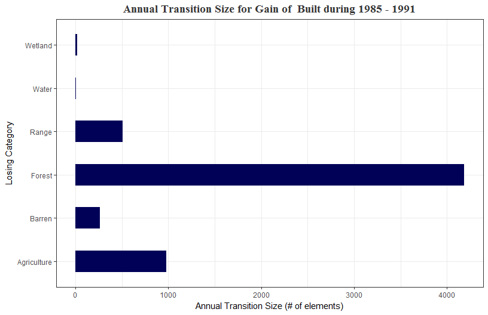

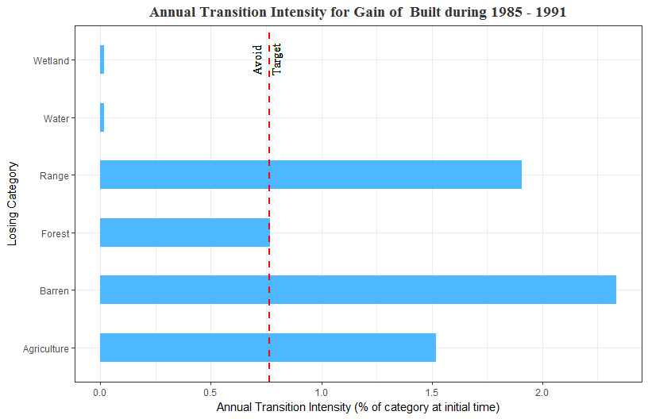

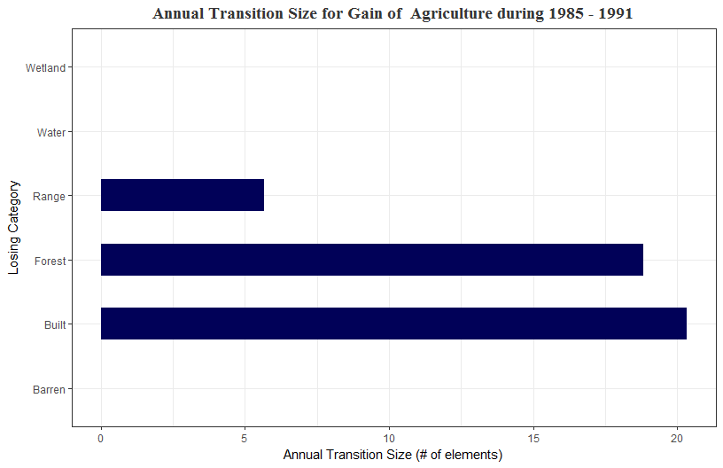

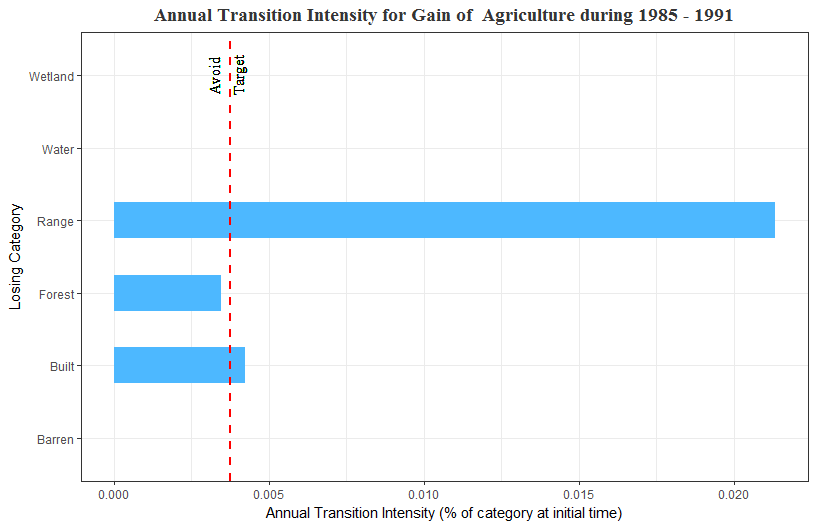

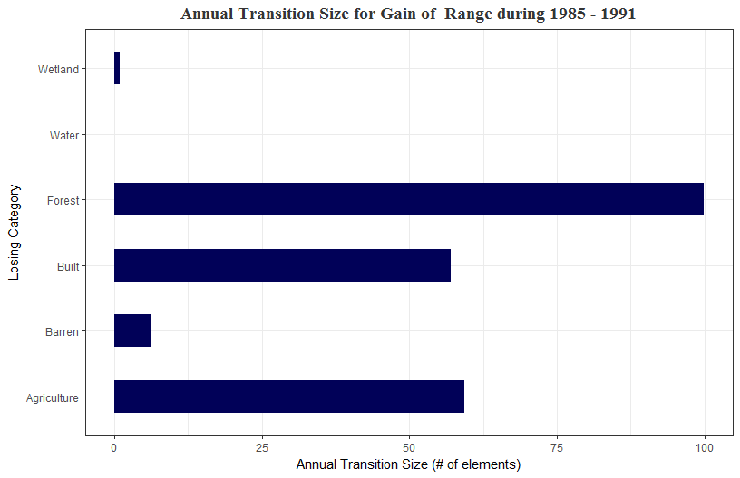

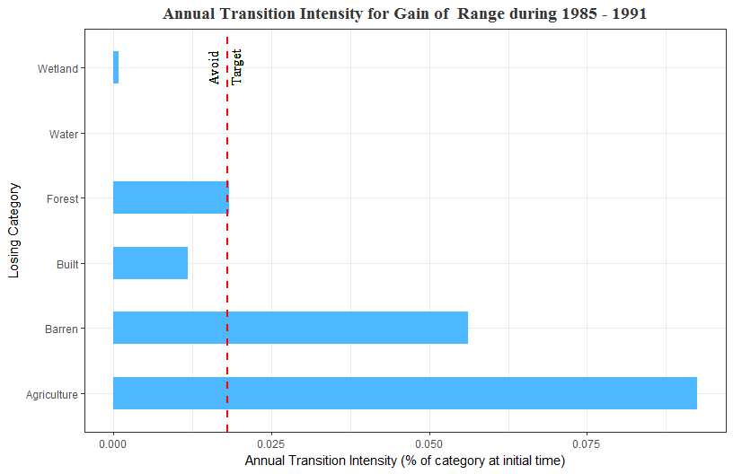

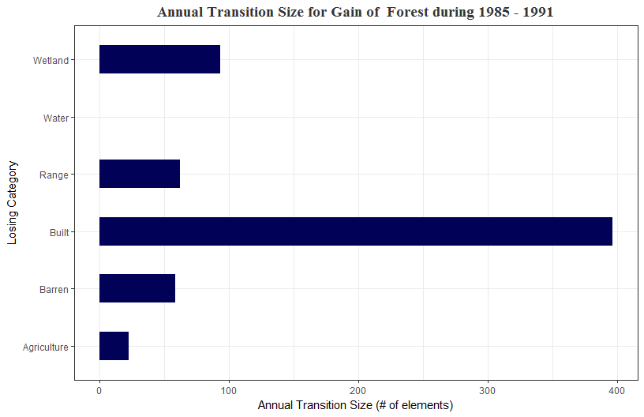

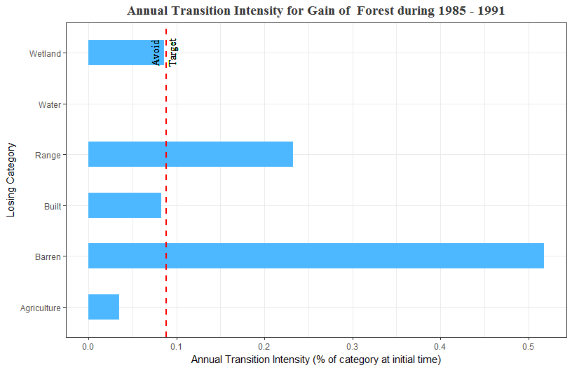

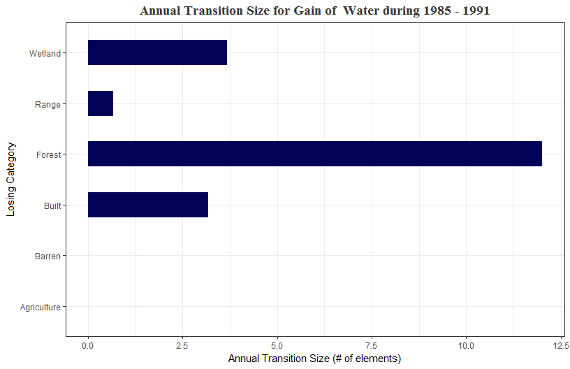

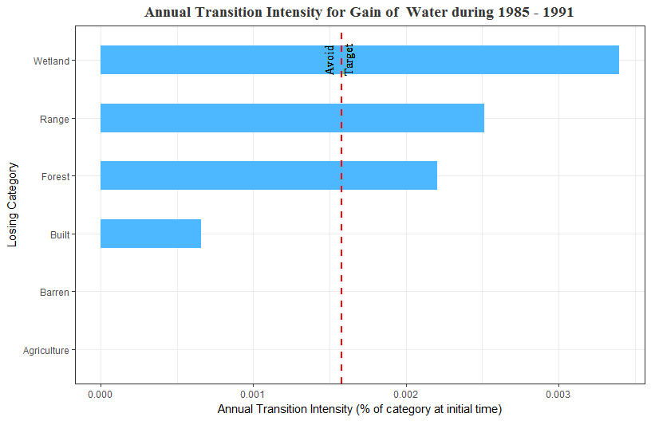

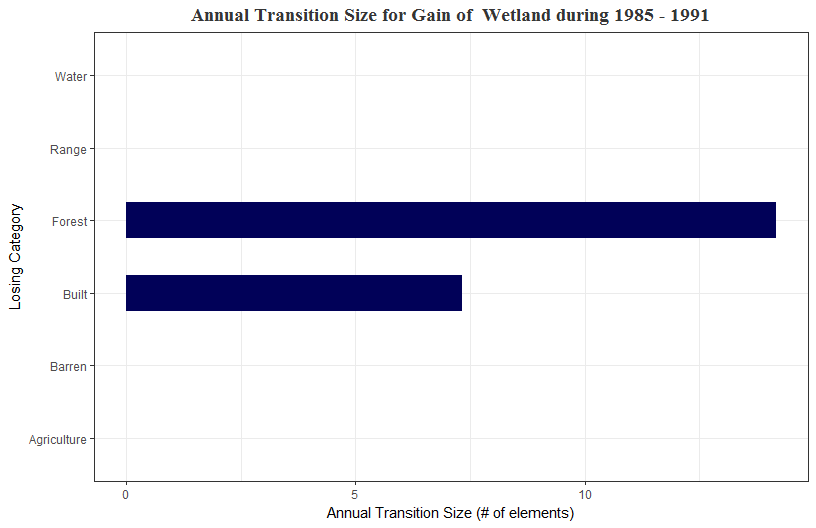

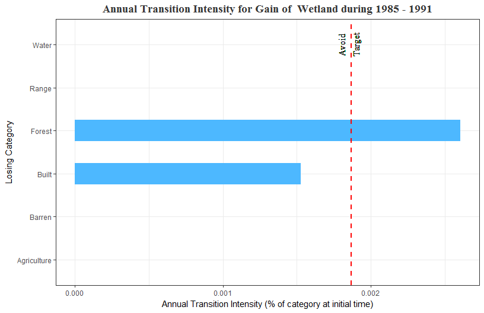

[16 more figures not shown]

The package produces “Annual Transition Size”, “Transition Intensity”, “Uniform Transition” and “Transition Behavior” for the gross gain of each category during each time interval.

```
#> $Annual.Transition.Size
#> $Annual.Transition.Size[[1]]
#>             Transition Size for Gain of Category  Built
#> Built                                                NA
#> Agriculture                                  976.333333
#> Range                                        506.000000
#> Forest                                      4181.666667
#> Water                                          4.166667
#> Wetland                                       19.000000
#> Barren                                       263.000000
#>             Transition Size for Gain of Category  Agriculture
#> Built                                               20.333333
#> Agriculture                                                NA
#> Range                                                5.666667
#> Forest                                              18.833333
#> Water                                                0.000000
#> Wetland                                              0.000000
#> Barren                                               0.000000
#>             Transition Size for Gain of Category  Range
#> Built                                        57.0000000
#> Agriculture                                  59.3333333
#> Range                                                NA
#> Forest                                       99.8333333
#> Water                                         0.0000000
#> Wetland                                       0.8333333
#> Barren                                        6.3333333
#>             Transition Size for Gain of Category  Forest
#> Built                                          396.00000
#> Agriculture                                     22.33333
#> Range                                           61.83333
#> Forest                                                NA
#> Water                                            0.00000
#> Wetland                                         93.00000
#> Barren                                          58.33333
#>             Transition Size for Gain of Category  Water
#> Built                                         3.1666667
#> Agriculture                                   0.0000000
#> Range                                         0.6666667
#> Forest                                       12.0000000
#> Water                                                NA
```

[output cut: 231 more lines]

```
#> Built       "Avoid"
#> Agriculture "Avoid"
#> Range       "Avoid"
#> Forest      "Target"
#> Water       "Target"
#> Wetland     NA
#> Barren      "Target"
#>             Transition Behavior for Gain of Category  Barren
#> Built       "Avoid"
#> Agriculture "Avoid"
#> Range       "Avoid"
#> Forest      "Target"
#> Water       "Target"
#> Wetland     "Avoid"
#> Barren      NA
```

The **TIA2csv** function reads the output of the **TIA** function and a directory variable as arguments then makes a CSV report of the Transition level Intensity Analysis and saves it in a folder named “CSVOutput” inside the provided path. The CSV file is named: “TransitionLevelIntensityAnalysis”.

```r
# Define a variable with the direction to store the csv results.
path <- "C:/AnalysisResults"
TIA2csv(TIA.output, path)
```

## References

Aldwaik,Safaa Zakaria and Robert Gilmore Pontius Jr. (2012). Intensity analysis to unify measurements of size and stationarity of land changes by interval, category, and transition. Landscape and Urban Planning. 106, 103-114.

Pontius Jr, Robert Gilmore, Yan Gao, Nicholas Giner, Takashi Kohyama, Mitsuru Osaki and Kazuyo Hirose. (2013). Design and Interpretation of Intensity Analysis Illustrated by Land Change in Central Kalimantan, Indonesia. Land. 2(3), 351-369.